# Assignment 1

Josephine Elder

February 11, 2025

R packages used in this report include GEOquery (Davis and Meltzer 2007), edgeR (Chen et al. 2024) and biomaRt (Durinck et al. 2009) (Durinck et al. 2005).

# Introduction

Epstein-Barr virus (EBV) is a very common virus, with approximately 90% of the human population world wide being infected. EBV is often asymptomatic but can in rare occasions be associated with severe side effects. Notably, it has been found that EBV can be oncogenic, and is associated with several types of cancers (Yu and Robertson 2023). Viruses often act to hijack cell machinery, changing gene expression in infected cells, which can be measured through RNA sequencing. Having taken multiple classes discussing the different effects that viruses can have on cells, understanding how viruses can affect expression of the host genome is very interesting to me. The data used in this report is RNAseq data on primary B cells that were transformed into lymphoblastoid cell lines, through EBV infection (Casco, Ohashi, and Johannsen 2024a). In the study, a dual-fluorescent lytic reporter is used, transforming the wild type EBV to a recombinant version that expresses GFP in early phase of infection and RFP in the later phase of infection. EBV goes through distinct phases in it’s infection cycle, which can be determined by the viral proteins that are being expressed (Hoover and Higginbotham 2025). The dataset can be found on GEO at GSE271717 (Casco, Ohashi, and Johannsen 2024b)

# The Dataset

## About the Data

Accession Number: GPL24676  
Platform: Illumina NovaSeq 6000 (Homo sapiens)  
Organism: Homo sapiens  
Date Submitted: Mar 02 2018

## Getting the Data

The supplementary material associated with the data was retrieved using `getGEOSuppFiles`. Only one `.tar` file was present, which was then downloaded. The `untar` function was used to access the files stored within the tar file, showing separate files for gene level and isoform level expression for each sample.

```r
# Get the name of the supplementary files
sfilenames = getGEOSuppFiles(data_set_geoid, fetch_files = FALSE)

# Download the supplementary files and untar to get individual files
data_filename <- sfilenames$fname
download_dir <- file.path(getwd())
missing_files <- sfilenames$fname[!unlist(lapply(sfilenames$fname, FUN=function(x) {
    file.exists(file.path(download_dir, data_set_geoid, x))}))]

if(length(missing_files) > 0){
    for(i in 1:length(missing_files)){
        sfiles = getGEOSuppFiles(data_set_geoid, filter_regex = missing_files[i], baseDir = download_dir, fetch_files = TRUE)
    }
    untar(tarfile = file.path(getwd(), "GSE271717", "GSE271717_RAW.tar"), exdir = getwd())
}
```

## Looking at the Data

The top file was read in, showing that it contains 63,419 genes and 7 different variables. The file shows the gene and transcript ids, the length of the gene, as well as values for RSEM expected counts, TPM and FPKM.

```r
# Read in the first file and look at the dimensions of the data as well as the first few lines
WT_02_genes <- read.table(file.path(getwd(),"GSM8383374_WT_02.genes.results.gz"), header = TRUE, check.names = TRUE)
dim(WT_02_genes)
```

```
## [1] 63419     7
```

```r
head(WT_02_genes)
```

|  | gene_id | transcript_id.s. | length | effective_length | expected_count | TPM | FPKM |
| --- | --- | --- | --- | --- | --- | --- | --- |
| 1 | BALF1 | BALF1 | 589 | 378.24 | 93.00 | 12.19 | 9.85 |
| 2 | BALF2 | BALF2 | 3795 | 3584.00 | 4246.29 | 58.75 | 47.48 |
| 3 | BALF3 | BALF3 | 4956 | 4745.00 | 380.77 | 3.98 | 3.22 |
| 4 | BALF4 | BALF4 | 2659 | 2448.00 | 5007.74 | 101.44 | 81.98 |
| 5 | BALF5 | BALF5 | 5044 | 4833.00 | 2091.81 | 21.46 | 17.35 |
| 6 | BARF1 | BARF1 | 690 | 479.06 | 241.00 | 24.95 | 20.16 |

The dataset contains multiple different sample conditions, which are summarized in the table below. The sample identifiers were pulled, and characteristics about the sample were put together into a matrix. `gsub` was used to remove reduntant wording in the table.

```r
# From lecture 4, get the information associated with each of the samples and clean to remove extra words
list_of_samples <- gse@gsms
sample_conditions <- do.call(rbind, lapply(list_of_samples, FUN = function(x) {
    c(x@header$title, x@header$characteristics_ch1)
}))
colnames(sample_conditions) <- c("name", "tissue", "cell line", "cell type", "genotype", "fraction")

sample_conditions[, "tissue"] <- gsub(sample_conditions[,"tissue"], pattern = "tissue: ",
                                replacement = "")
sample_conditions[, "cell line"] <- gsub(sample_conditions[,"cell line"], pattern = "cell line: ",
                                replacement = "")
sample_conditions[, "cell type"] <- gsub(sample_conditions[,"cell type"], pattern = "cell type: ",
                                replacement = "")
sample_conditions[, "genotype"] <- gsub(sample_conditions[,"genotype"], pattern = "genotype: ",
                                replacement = "")
sample_conditions[, "fraction"] <- gsub(sample_conditions[,"fraction"], pattern = "fraction: ",
                                replacement = "")
knitr::knit_print(knitr::kable(sample_conditions))
```

|  | name | tissue | cell line | cell type | genotype | fraction |
| --- | --- | --- | --- | --- | --- | --- |
| GSM8383374 | DFLR LCL, bulk fraction, c3-1 | Blood | LCL | EBV-transformed B cell | WT | Bulk |
| GSM8383375 | DFLR LCL, latent fraction, c3-1 | Blood | LCL | EBV-transformed B cell | WT | Latent |
| GSM8383376 | DFLR LCL, early lytic fraction, c3-1 | Blood | LCL | EBV-transformed B cell | WT | Early lytic |
| GSM8383377 | DFLR LCL, late lytic fraction, c3-1 | Blood | LCL | EBV-transformed B cell | WT | Late lytic |
| GSM8383378 | DFLR LCL, bulk fraction, c3-2 | Blood | LCL | EBV-transformed B cell | WT | Bulk |
| GSM8383379 | DFLR LCL, latent fraction, c3-2 | Blood | LCL | EBV-transformed B cell | WT | Latent |
| GSM8383380 | DFLR LCL, early lytic fraction, c3-2 | Blood | LCL | EBV-transformed B cell | WT | Early lytic |
| GSM8383381 | DFLR LCL, late lytic fraction, c3-2 | Blood | LCL | EBV-transformed B cell | WT | Late lytic |
| GSM8383382 | DFLR LCL, bulk fraction, c3-3 | Blood | LCL | EBV-transformed B cell | WT | Bulk |
| GSM8383383 | DFLR LCL, latent fraction, c3-3 | Blood | LCL | EBV-transformed B cell | WT | Latent |
| GSM8383384 | DFLR LCL, early lytic fraction, c3-3 | Blood | LCL | EBV-transformed B cell | WT | Early lytic |
| GSM8383385 | DFLR LCL, late lytic fraction, c3-3 | Blood | LCL | EBV-transformed B cell | WT | Late lytic |
| GSM8383386 | DFLR LCL, bulk fraction, c4-1 | Blood | LCL | EBV-transformed B cell | WT | Bulk |
| GSM8383387 | DFLR LCL, latent fraction, c4-1 | Blood | LCL | EBV-transformed B cell | WT | Latent |
| GSM8383388 | DFLR LCL, early lytic fraction, c4-1 | Blood | LCL | EBV-transformed B cell | WT | Early lytic |
| GSM8383389 | DFLR LCL, late lytic fraction, c4-1 | Blood | LCL | EBV-transformed B cell | WT | Late lytic |
| GSM8383390 | DFLR LCL, bulk fraction, c4-2 | Blood | LCL | EBV-transformed B cell | WT | Bulk |
| GSM8383391 | DFLR LCL, latent fraction, c4-2 | Blood | LCL | EBV-transformed B cell | WT | Latent |
| GSM8383392 | DFLR LCL, early lytic fraction, c4-2 | Blood | LCL | EBV-transformed B cell | WT | Early lytic |
| GSM8383393 | DFLR LCL, late lytic fraction, c4-2 | Blood | LCL | EBV-transformed B cell | WT | Late lytic |
| GSM8383394 | DFLR dBGLF5 LCL, latent fraction, c2-1 | Blood | LCL | EBV-transformed B cell | dBGLF5 | Latent |
| GSM8383395 | DFLR dBGLF5 LCL, early lytic fraction, c2-1 | Blood | LCL | EBV-transformed B cell | dBGLF5 | Early lytic |
| GSM8383396 | DFLR dBGLF5 LCL, late lytic fraction, c2-1 | Blood | LCL | EBV-transformed B cell | dBGLF5 | Late lytic |
| GSM8383397 | DFLR dBGLF5 LCL, latent fraction, c2-2 | Blood | LCL | EBV-transformed B cell | dBGLF5 | Latent |
| GSM8383398 | DFLR dBGLF5 LCL, early lytic fraction, c2-2 | Blood | LCL | EBV-transformed B cell | dBGLF5 | Early lytic |
| GSM8383399 | DFLR dBGLF5 LCL, late lytic fraction, c2-2 | Blood | LCL | EBV-transformed B cell | dBGLF5 | Late lytic |
| GSM8383400 | DFLR dBGLF5 LCL, latent fraction, c2-3 | Blood | LCL | EBV-transformed B cell | dBGLF5 | Latent |
| GSM8383401 | DFLR dBGLF5 LCL, early lytic fraction, c2-3 | Blood | LCL | EBV-transformed B cell | dBGLF5 | Early lytic |
| GSM8383402 | DFLR dBGLF5 LCL, late lytic fraction, c2-3 | Blood | LCL | EBV-transformed B cell | dBGLF5 | Late lytic |

## Selecting Samples

10 samples were selected for further analysis, looking at the 5 wild type cell lines, comparing the gene expression during the latent phase of infection and the late lytic phase of infection, with 5 samples for each condition.

```r
# Final samples that will be used in analysis
WT_samples <- sample_conditions[sample_conditions[,"genotype"] =="WT",]
latent_samples <- WT_samples[WT_samples[,"fraction"] == "Latent",]
late_lytic_samples <- WT_samples[WT_samples[,"fraction"] == "Late lytic",]

# Print a table of the sample characteristics
final_samples <- sample_conditions[rownames(latent_samples),]
final_samples <- rbind(final_samples, sample_conditions[rownames(late_lytic_samples),])
knitr::knit_print(knitr::kable(final_samples))
```

|  | name | tissue | cell line | cell type | genotype | fraction |
| --- | --- | --- | --- | --- | --- | --- |
| GSM8383375 | DFLR LCL, latent fraction, c3-1 | Blood | LCL | EBV-transformed B cell | WT | Latent |
| GSM8383379 | DFLR LCL, latent fraction, c3-2 | Blood | LCL | EBV-transformed B cell | WT | Latent |
| GSM8383383 | DFLR LCL, latent fraction, c3-3 | Blood | LCL | EBV-transformed B cell | WT | Latent |
| GSM8383387 | DFLR LCL, latent fraction, c4-1 | Blood | LCL | EBV-transformed B cell | WT | Latent |
| GSM8383391 | DFLR LCL, latent fraction, c4-2 | Blood | LCL | EBV-transformed B cell | WT | Latent |
| GSM8383377 | DFLR LCL, late lytic fraction, c3-1 | Blood | LCL | EBV-transformed B cell | WT | Late lytic |
| GSM8383381 | DFLR LCL, late lytic fraction, c3-2 | Blood | LCL | EBV-transformed B cell | WT | Late lytic |
| GSM8383385 | DFLR LCL, late lytic fraction, c3-3 | Blood | LCL | EBV-transformed B cell | WT | Late lytic |
| GSM8383389 | DFLR LCL, late lytic fraction, c4-1 | Blood | LCL | EBV-transformed B cell | WT | Late lytic |
| GSM8383393 | DFLR LCL, late lytic fraction, c4-2 | Blood | LCL | EBV-transformed B cell | WT | Late lytic |

Each of the corresponding files for the 10 selected samples was then read in, with 5 latent samples and 5 late lytic samples.

```r
# Read in the data from the samples that will be used
latent_1 <- read.table(file.path(getwd(), "GSM8383375_WT_03.genes.results.gz"), header = TRUE, check.names = TRUE)
latent_2 <- read.table(file.path(getwd(), "GSM8383379_WT_08.genes.results.gz"), header = TRUE, check.names = TRUE)
latent_3 <- read.table(file.path(getwd(), "GSM8383383_WT_13.genes.results.gz"), header = TRUE, check.names = TRUE)
latent_4 <- read.table(file.path(getwd(), "GSM8383387_WT_18.genes.results.gz"), header = TRUE, check.names = TRUE)
latent_5 <- read.table(file.path(getwd(), "GSM8383391_WT_23.genes.results.gz"), header = TRUE, check.names = TRUE)
late_lytic_1 <- read.table(file.path(getwd(), "GSM8383377_WT_05.genes.results.gz"), header = TRUE, check.names = TRUE)
late_lytic_2 <- read.table(file.path(getwd(), "GSM8383381_WT_10.genes.results.gz"), header = TRUE, check.names = TRUE)
late_lytic_3 <- read.table(file.path(getwd(), "GSM8383385_WT_15.genes.results.gz"), header = TRUE, check.names = TRUE)
late_lytic_4 <- read.table(file.path(getwd(), "GSM8383389_WT_20.genes.results.gz"), header = TRUE, check.names = TRUE)
late_lytic_5 <- read.table(file.path(getwd(), "GSM8383393_WT_25.genes.results.gz"), header = TRUE, check.names = TRUE)
```

From each of the files, only the gene IDs and the corresponding RSEM read counts were extracted, and then added to a data frame matching by gene id, with the column name indicating the sample. The initial dataset contains count data for the viral genome as well as for spike ins, which were removed from the data as they are not from the human genome. This removed around 200 genes from the dataset, making the total number of human genes analyzed in the data 63,241.

```r
# Function to only get the raw expression counts from the data file
get_gene_counts <- function(x, column_name) {
    new_data <- data.frame(x[,"gene_id"], x[,"expected_count"])
    colnames(new_data) <- c("gene_id", column_name)
    return(new_data)
}
# Function to add the counts to existing data frame
add_gene_counts <- function(x, column_name, full) {
    new_data <- get_gene_counts(x, column_name)
    return(merge(full, new_data, by = "gene_id"))
}


all_samples_gene_counts <- data.frame(gene_id = latent_1[,"gene_id"], latent_1 = latent_1[,"expected_count"])
all_samples_gene_counts <- add_gene_counts(latent_2, "latent_2", all_samples_gene_counts)
all_samples_gene_counts <- add_gene_counts(latent_3, "latent_3", all_samples_gene_counts)
all_samples_gene_counts <- add_gene_counts(latent_4, "latent_4", all_samples_gene_counts)
all_samples_gene_counts <- add_gene_counts(latent_5, "latent_5", all_samples_gene_counts)
all_samples_gene_counts <- add_gene_counts(late_lytic_1, "late_lytic_1", all_samples_gene_counts)
all_samples_gene_counts <- add_gene_counts(late_lytic_2, "late_lytic_2", all_samples_gene_counts)
all_samples_gene_counts <- add_gene_counts(late_lytic_3, "late_lytic_3", all_samples_gene_counts)
all_samples_gene_counts <- add_gene_counts(late_lytic_4, "late_lytic_4", all_samples_gene_counts)
all_samples_gene_counts <- add_gene_counts(late_lytic_5, "late_lytic_5", all_samples_gene_counts)

# Removing counts mapped to EBV genome and spike ins
all_samples_gene_counts <- subset(all_samples_gene_counts, grepl("^ENSG", gene_id))
```

## Visualizing Data

A boxplot was made, visualizing the distribution of counts of all human genes that were measured across each of the samples, prior to any cleaning or normalization of the data. Notably, a large portion of the genes have expression counts of 0, leading to many of the genes having a value of -inf when taking the log, making it difficult to make conclusions about the distribution of the data from the boxplot.

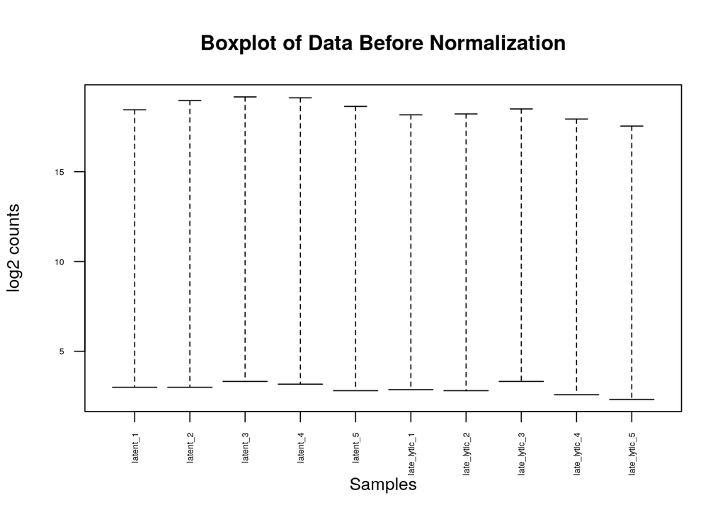

A boxplot showing the distribution of log of gene counts for all genes initially in the dataset for each sample. Many of the genes have expression of 0, leading to a inf value in the boxplot.

```r
# From lecture 5 visualizing the data in a boxplot
ebv_expr_data <- data.frame(all_samples_gene_counts[,2:11], row.names = all_samples_gene_counts[,1])
boxplot(log2(ebv_expr_data), xlab = "Samples", ylab = "log2 counts", range = 2, las = 2, cex = 1, cex.lab = 1, cex.axis = 0.5, main = "Boxplot of Data Before Normalization")
```

To get a better idea of the distribution of the data, a density plot was created. Density data for each sample was plotted together, showing differences in distribution. The plot shows a very uneven and noisy distribution of data.

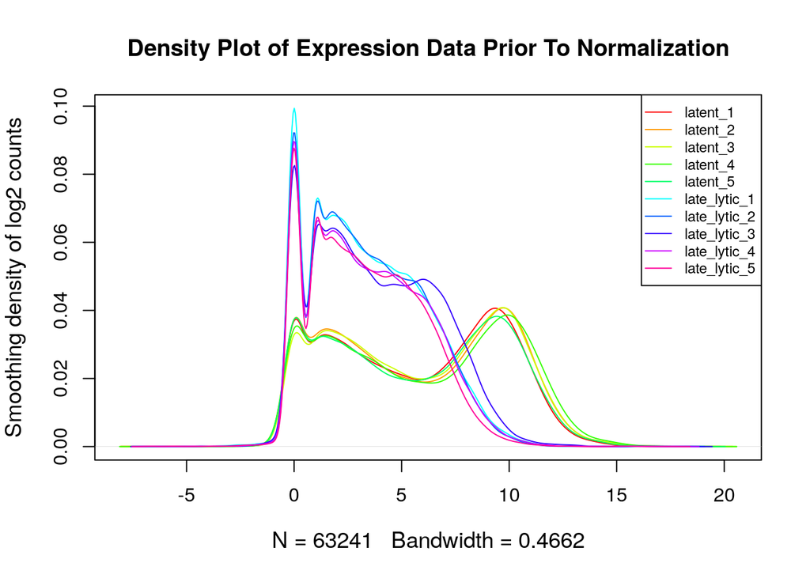

Visualization of data distribution prior to normalization using a density plot.

```r
# From lecture 5 creating a density plot

# Calculate density for each sample
count_density <- apply(log2(ebv_expr_data), MARGIN = 2, FUN = density)
xlim <- 0; ylim <- 0
for (i in 1:length(count_density)) {
    xlim <- range(c(xlim, count_density[[i]]$x))
    ylim <- range(c(ylim, count_density[[i]]$y))
}

# Choose colours and line style for plot
cols <- rainbow(length(count_density))
ltys <- rep(1, length(count_density))

# Plot the data
plot(count_density[[1]], xlim = xlim, ylim = ylim, type = "n", ylab = "Smoothing density of log2 counts", main = "Density Plot of Expression Data Prior To Normalization", cex.lab = 1.15)
for (i in 1: length(count_density)) {
    lines(count_density[[i]], col=cols[i], lty = ltys[i])
}
# Creating a legend
legend("topright", colnames(log2(ebv_expr_data)), col=cols, lty = ltys, cex = 0.75, merge = TRUE)
```

# Cleaning

## Cleaning Data

Next genes that were very lowly expressed were removed, as it was noted earlier that many genes had very low expression, or often had expression counts of 0. The minimum samples used was 5, half of the total samples present, as it allowed for sufficient removal of lowly expressed genes without removing the entirety of the data. After removing lowly expressed genes, there are 14,007 genes left in the dataset.

```r
# Filtering out lowly expressed genes by looking at expression across all samples
min_samples <- 5
ebv_matrix <- as.matrix(ebv_expr_data)
keep <-  rowSums(cpm(ebv_matrix) > 1) > min_samples
filtered_ebv_matrix <- ebv_matrix[keep,]
```

# Mapping

The human gene IDs used in the dataset were ensemble IDs with version IDs. Version IDs were removed from the rownames to increase the number of mapped genes. Corresponding HGNC symbols were retrieved using biomaRt. HGNC symbols were merged with the normalized count data by matching ensemble IDs. Of the 14,007 genes from the data, 92 did not map to a corresponding HGNC symbol. The ensembl IDs for those 92 genes have been retired and are no longer in use. Since only a very small portion of the genes did not map to the HGNC symbol, they will be disregarded.

```r
# From lecture 5
# Remove the version ID from the ensembl ID
rownames(filtered_ebv_matrix) <- unlist(lapply(rownames(filtered_ebv_matrix), FUN = function(x){unlist(strsplit(x, split = "\\."))[1]}))

# Using a different mirror
ensembl <- useEnsembl("ensembl", "hsapiens_gene_ensembl", mirror = "useast")

# Associate ensembl ID with the HGNC symbols
to_convert <- rownames(filtered_ebv_matrix)
conversion_stash <- "id_conversion.rds"
if(file.exists(conversion_stash)) {
    id_conversion <- readRDS(conversion_stash)
} else {
    id_conversion <- getBM(attributes = c("ensembl_gene_id", "hgnc_symbol"), filters = c("ensembl_gene_id"), values = to_convert, mart = ensembl)
    saveRDS(id_conversion, conversion_stash)
}

# Calculating the number of ensembl IDs that are not mapped
nrow(filtered_ebv_matrix) - length(which(rownames(filtered_ebv_matrix) %in% id_conversion$ensembl_gene_id))
```

```
## [1] 92
```

```r
# Merge the data with the ensemble ID to HGNC symbol conversions
ant_ebv <- merge(id_conversion, filtered_ebv_matrix, by.x = 1, by.y = 0, all.y = TRUE)

# Get the IDs for genes
missing_ids_genes <- ant_ebv$ensembl_gene_id[which(is.na(ant_ebv$hgnc_symbol))]
```

```r
# Get the total number of unique HGNC symbols to see what is duplicated
length(unique(ant_ebv$hgnc_symbol))
```

```
## [1] 12983
```

```r
# Removing data from ensembl IDs that do not have an HGNC symbol
ant_ebv <- ant_ebv[!ant_ebv$hgnc_symbol == "",]
```

After removing genes without HGNC symbols, there were 27 genes that mapped to an HGNC symbol that had already been mapped to. Many of the genes had the exact same expression values for each sample, and were likely exact duplicates of the data. Additionally, the samples in `not_unique` all use a different ensembl ID from what is listed in the HGNC website. Thus the duplicated samples that used the different ensembl ID were removed.

```r
# Getting the data from duplicates
not_unique <- ant_ebv[duplicated(ant_ebv$hgnc_symbol),]

# Getting symbols to remove
symbols_to_remove <- not_unique$ensembl_gene_id

# Removing duplicates
ant_ebv <- ant_ebv[!ant_ebv$ensembl_gene_id %in% symbols_to_remove,]

# Reformatting to have HGNC symbols as row names
ant_ebv <- data.frame(ant_ebv[,3:12], row.names = ant_ebv[,2])
```

## Visualizing After Cleaning and Mapping

A boxplot of the data after removal of the lowly expressed genes and genes that do not map is much more informative in showing the distribution of data across samples. However, it still shows a difference in the median and quartiles of the data.

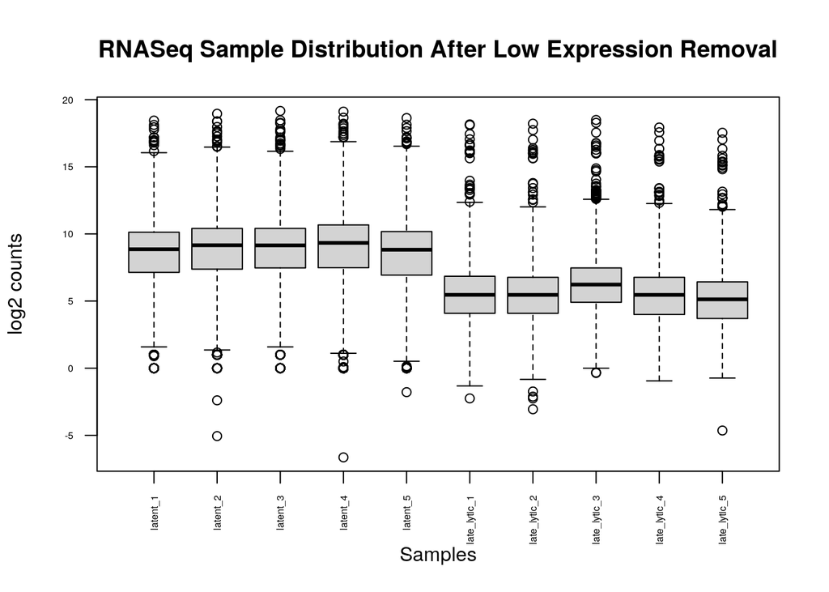

Boxplot showing distribution of gene counts after removing lowly expressed genes.

```r
# From lec 5, boxplot after cleaning data
boxplot(log2(ant_ebv), xlab = "Samples", ylab = "log2 counts", range = 2, las = 2, cex = 1, cex.lab = 1, cex.axis = 0.5, main = "RNASeq Sample Distribution After Low Expression Removal")
```

A density plot was made again with the cleaned data, showing less noise after the removal of lowly expressed genes.

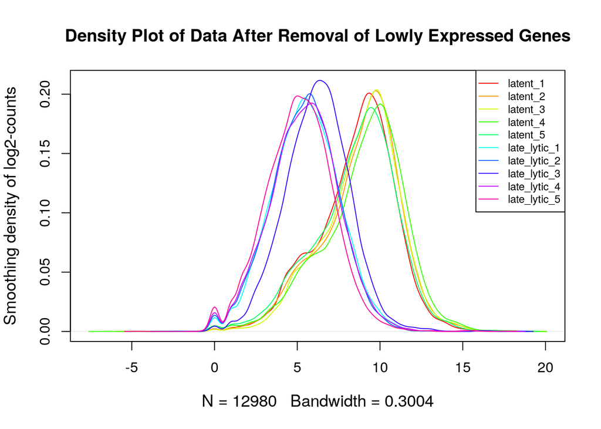

Distribution of gene expression for all samples after the removal of lowly expressed genes

```r
# From lec 5, plotting density after cleaning data

count_density <- apply(log2(ant_ebv), MARGIN = 2, FUN = density)
xlim <- 0; ylim <- 0
for (i in 1:length(count_density)) {
    xlim <- range(c(xlim, count_density[[i]]$x))
    ylim <- range(c(ylim, count_density[[i]]$y))
}

plot(count_density[[1]], xlim = xlim, ylim = ylim, type = "n", ylab = "Smoothing density of log2-counts", main = "Density Plot of Data After Removal of Lowly Expressed Genes", cex.lab = 1.15)
for (i in 1: length(count_density)) {
    lines(count_density[[i]], col=cols[i], lyt = ltys[i])
}
legend("topright", colnames(log2(ant_ebv)), col=cols, lty = ltys, cex = 0.75, merge = TRUE)
```

# Normalizing

## Normalizing Data

Data was then normalized using `DGEList` from the edgeR package to get TMM values, grouping the samples by their fraction, either latent or late lytic. The normalized counts were then converted into counts per million.

```r
# TMM normalization grouping by fraction, from lec 5

normalizing <- DGEList(counts = ant_ebv, group = final_samples[,"fraction"])
normalizing <- calcNormFactors(normalizing)
normalized_counts <- cpm(normalizing)
```

## Visualizing After Normalization

The boxplot of the normalized read counts now shows that the median between all of the samples are aligned.

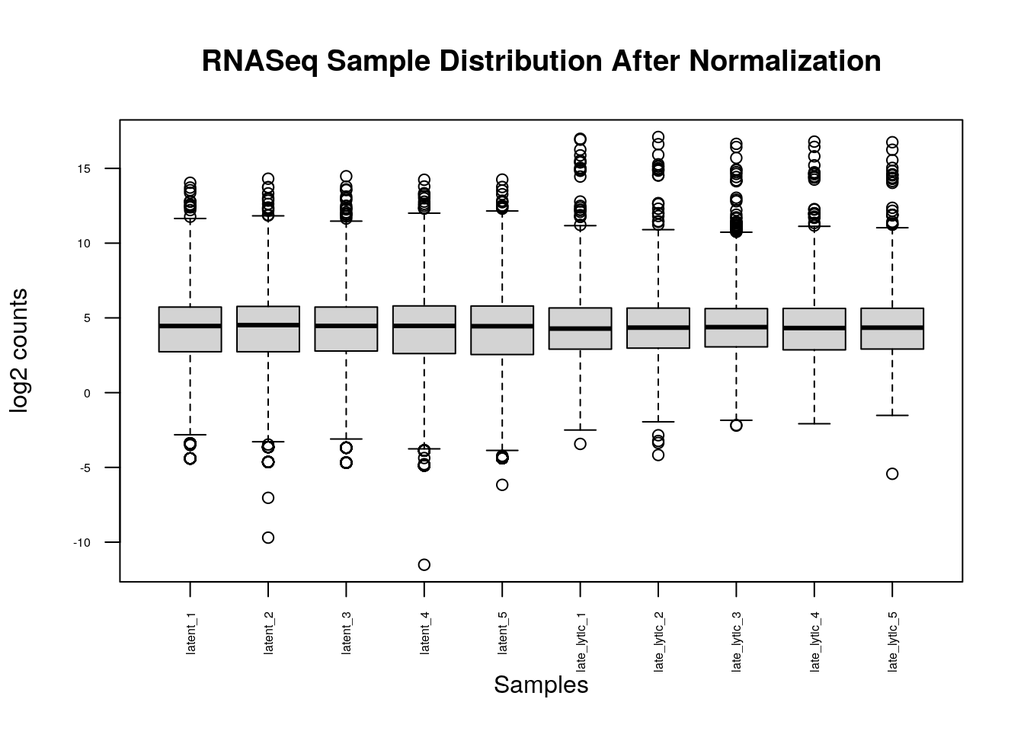

Boxplot showing distribution of gene counts after normalization.

```r
# From lec 5, boxplot of data post normalization

boxplot(log2(normalized_counts), xlab = "Samples", ylab = "log2 counts", range = 2, las = 2, cex = 1, cex.lab = 1, cex.axis = 0.5, main = "RNASeq Sample Distribution After Normalization")
```

Plotting a density function after normalization shows that the peaks between all of the samples align much better than previously and show less noise than before.

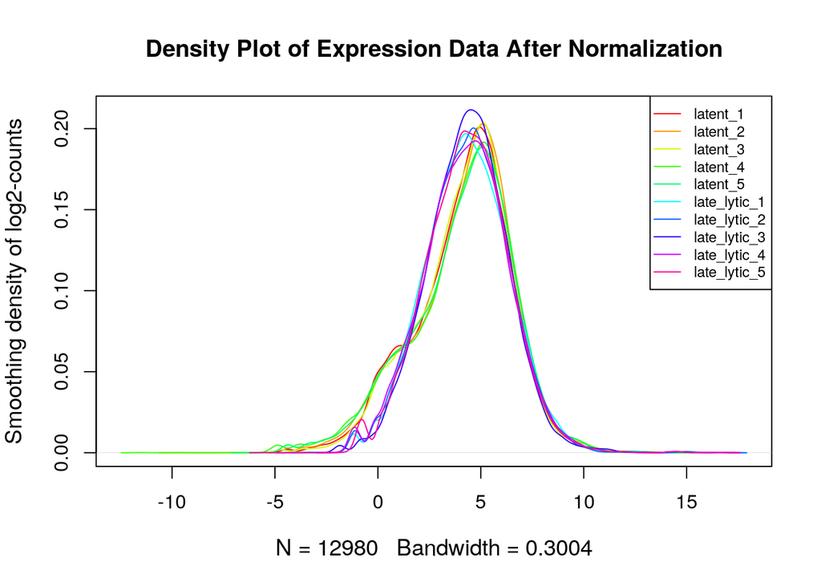

```r
# From lec 5, density plot post normalization

count_density <- apply(log2(normalized_counts), MARGIN = 2, FUN = density)
xlim <- 0; ylim <- 0
for (i in 1:length(count_density)) {
    xlim <- range(c(xlim, count_density[[i]]$x))
    ylim <- range(c(ylim, count_density[[i]]$y))
}

plot(count_density[[1]], xlim = xlim, ylim = ylim, type = "n", ylab = "Smoothing density of log2-counts", main = "Density Plot of Expression Data After Normalization", cex.lab = 1.15)
for (i in 1: length(count_density)) {
    lines(count_density[[i]], col=cols[i], lyt = ltys[i])
}
legend("topright", colnames(log2(normalized_counts)), col=cols, lty = ltys, cex = 0.75, merge = TRUE)
```

Plotting an MDS plot shows the similarity between the two groups. In this case there is good separation between the two sample groups, indicating that the comparison between latent and late lytic fractions has many differences.

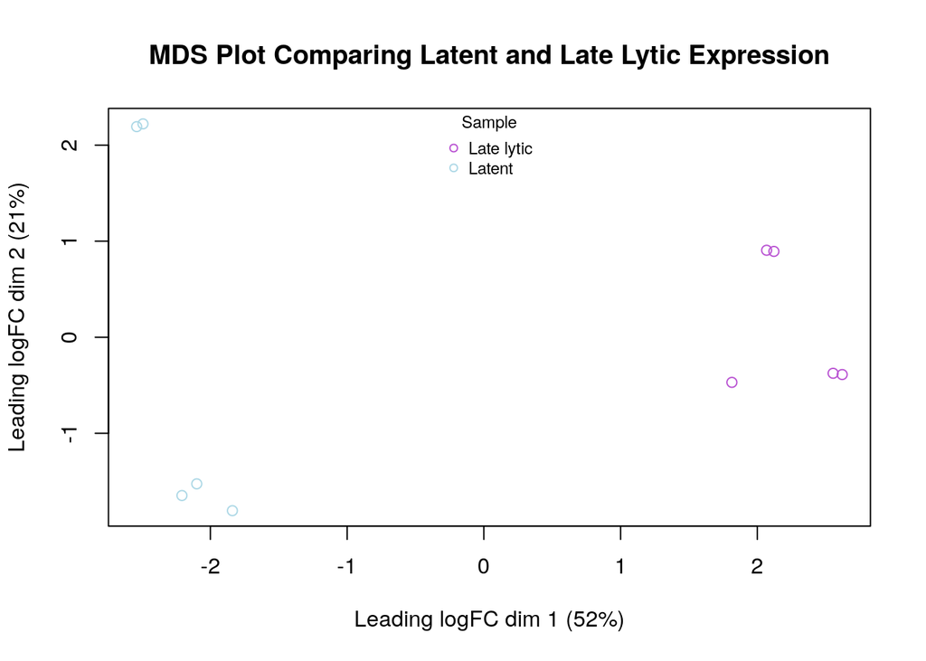

Multidimentional scaling plot showing the difference between expression in the two sample groups

```r
# From lec 5, MDS plot, shows similarity between sample groups

limma::plotMDS(normalizing, labels=NULL, pch = 1, main = "MDS Plot Comparing Latent and Late Lytic Expression", col = c("mediumorchid", "lightblue") [factor(final_samples[,"fraction"])])
legend("top", legend = levels(factor(final_samples[,"fraction"])), pch = c(1), col = c("mediumorchid", "lightblue"), title = "Sample", bty = "n", cex = 0.75)
```

A BCV plot was plotted to show the relationship between the biological coefficient of variation and the average gene expression.

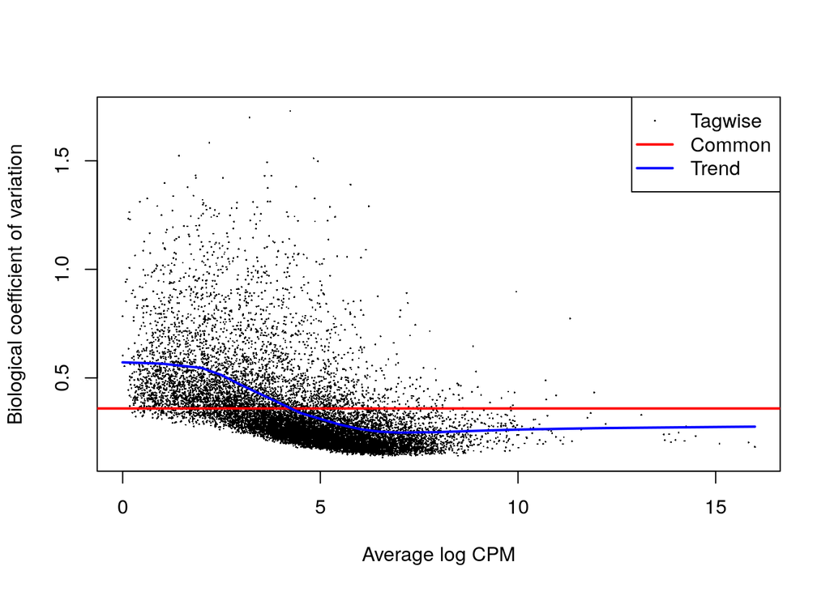

Plot showing changes in the biological coefficient of variation by different read counts.

```r
# Fron lec 5, BCV plot, shows variation by read counts

ebv_model <- model.matrix(~final_samples[,"fraction"])
disp <- estimateDisp(normalizing, ebv_model)
plotBCV(disp, col.tagwise = "black", col.common = "red")
```

Finally, a mean-variance plot was made, showing the general distribution that the data follows. Looking at the plot, the data all appears to follow the negative binomial distribution well, and there are no clear outliers that can be identified from this plot, thus no outliers were removed. Similarly, in the paper from this dataset, only lowly expressed genes were removed, and no outliers were removed.

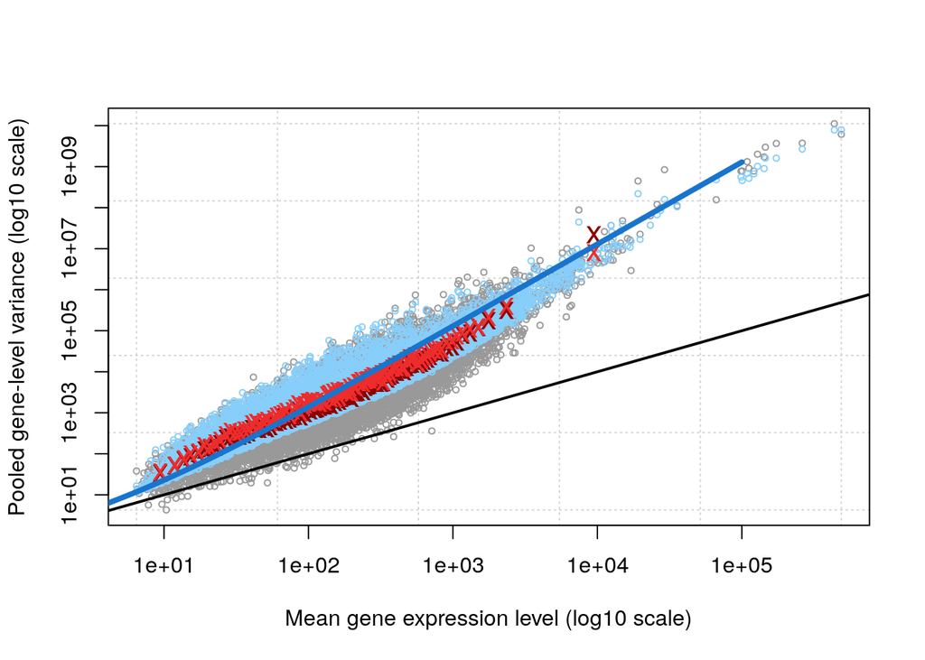

Visualization of the relationship between the mean and variance. The data matches well with the negative binomial distribution.

```r
# From lec 5, mean-var plot shows relationship between mean and variance of data to undertand what distribution it follows, blue line is negative binom

plotMeanVar(disp, show.raw.vars = TRUE, show.tagwise.vars = TRUE, show.ave.raw.vars = TRUE, NBline = TRUE, show.binned.common.disp.vars = TRUE)
```

# Final Data

The final dataset that is produced has HGNC identifiers as the row names, with each of the 10 samples in a different column. TMM normalized counts for each gene by sample is shown in the data. Of the initial 63,419 genes, 12,980 genes were kept for analysis.

```r
# Finalized data set, looking at the top of data and total number of rows to get total number of genes

final_data <- normalized_counts
head(final_data)
```

```
##       latent_1 latent_2 latent_3 latent_4 latent_5 late_lytic_1 late_lytic_2
## DPM1  44.27843 59.18198 58.73335 50.55843 56.47751    67.602027    87.902710
## SCYL3 25.07219 15.31675 20.79559 28.94077 27.40439    28.719815    37.474313
## FIRRM 24.78835 28.74897 25.77098 29.00781 31.19589    29.603502    26.370813
## FGR   22.13921 85.64547 71.83224 60.92325 52.45708     7.069493    14.804667
## FUCA2 25.35602 25.02002 26.44033 24.18458 23.51690     3.092903     3.238521
## GCLC  18.35473 17.60223 15.23714 17.06946 16.02989     8.395023    13.416729
##       late_lytic_3 late_lytic_4 late_lytic_5
## DPM1     73.127349    75.498685     60.92625
## SCYL3    23.078213    21.830945     31.91375
## FIRRM    18.073299    19.556888     13.92600
## FGR      12.790335    27.288681     21.46925
## FUCA2     8.341523     4.093302      4.64200
## GCLC      9.239627    10.833607     12.76550
```

```r
nrow(final_data)
```

```
## [1] 12980
```

# Questions

1. Why is the dataset of interest to you? Introduction
2. What are the control and test conditions of the dataset? About the Data Selecting Samples
3. How many samples are in each condition of your dataset? Selecting Samples
4. Were there expression values that were not unique for specific genes? How did you handle these? Mapping
5. Were there expression values that could not be mapped to current HUGO symbols? Mapping
6. Where there any outliers in your dataset? How were they handled in the originating paper? How many outliers were removed? Visualizing After Normalization
7. How did you handle replicates? Mapping
8. What is the final coverage of your dataset? Final Data

# References

Casco, Alejandro, Makoto Ohashi, and Eric Johannsen. 2024a. “Epstein-Barr Virus Induces Host Shutoff Extensively via BGLF5-Independent Mechanisms.” *Cell Reports* 43 (10).

———. 2024b. “Epstein-Barr Virus Induces Host Shutoff Extensively via BGLF5-Independent Mechanisms [RNA-Seq].” https://www.ncbi.nlm.nih.gov/geo/query/acc.cgi?acc=GSE271717.

Chen, Yunshun, Lizhong Chen, Aaron T L Lun, Pedro Baldoni, and Gordon K Smyth. 2024. “edgeR 4.0: Powerful Differential Analysis of Sequencing Data with Expanded Functionality and Improved Support for Small Counts and Larger Datasets.” *bioRxiv*. https://doi.org/10.1101/2024.01.21.576131.

Davis, Sean, and Paul Meltzer. 2007. “GEOquery: A Bridge Between the Gene Expression Omnibus (GEO) and BioConductor.” *Bioinformatics* 14: 1846–47. https://doi.org/10.1093/bioinformatics/btm254.

Durinck, Steffen, Yves Moreau, Arek Kasprzyk, Sean Davis, Bart De Moor, Alvis Brazma, and Wolfgang Huber. 2005. “BioMart and Bioconductor: A Powerful Link Between Biological Databases and Microarray Data Analysis.” *Bioinformatics* 21: 3439–40.

Durinck, Steffen, Paul T. Spellman, Ewan Birney, and Wolfgang Huber. 2009. “Mapping Identifiers for the Integration of Genomic Datasets with the r/Bioconductor Package biomaRt.” *Nature Protocols* 4: 1184–91.

Hoover, Karla, and Karla Higginbotham. 2025. “Epstein-Barr Virus.” In. Treasure Island (FL): StatPearls Publishing. http://www.ncbi.nlm.nih.gov/books/NBK559285/.

Yu, Hui, and Erle S. Robertson. 2023. “Epstein–Barr Virus History and Pathogenesis.” *Viruses* 15 (3). https://doi.org/10.3390/v15030714.